# University at Buffalo (Buffalo, NY)

### Students from US

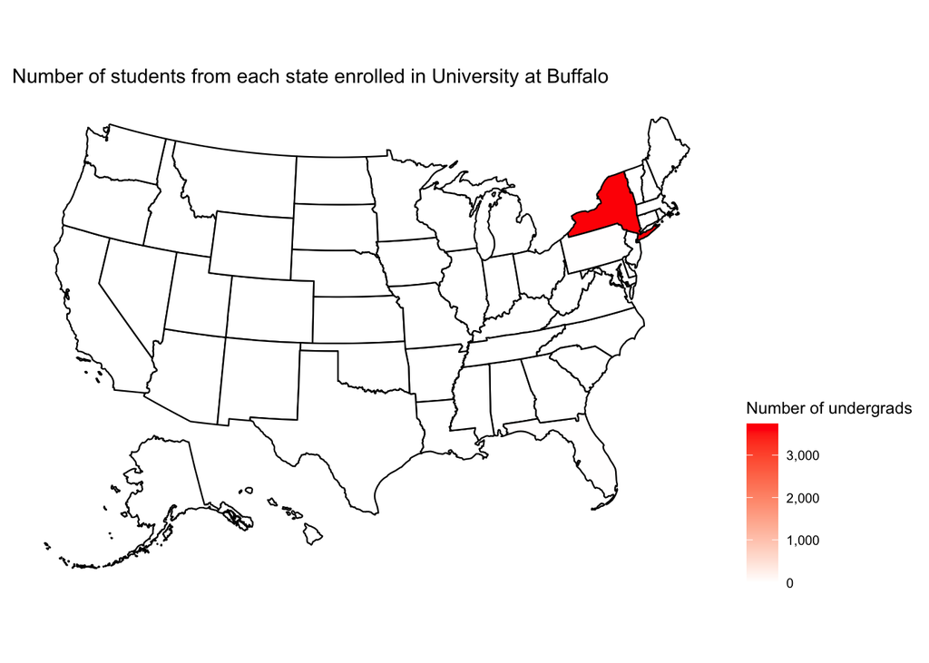

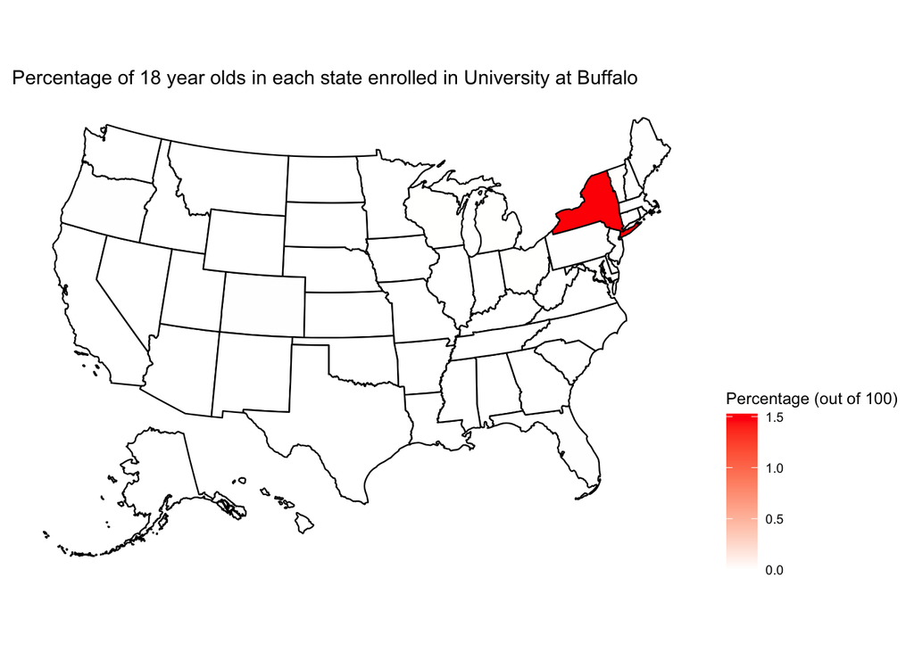